# Churn Analysis

Kevin Baca

4/15/2019

Exploration, Tidying, Plotting and Modeling based on the public WA_Fn-UseC_-Telco-Customer-Churn data set.

## Index

- Project Overview
- Exploring Demographic Data
- Exploring Adoption Data
- Exploring Payment Data
- Tidying Data
- Correlation Matrix
- Decision Tree
- Training Dataset
- Logistic Regression

## Project Overview

#### Problem Statement

Customer Churn is a metric used by subscripton-based businesses to measure the number of customers lost in a given amount of time. MRR Churn, in particular, is a widely-used financial metric that calculates the amount of monthly recurring revenue (MRR) lost each month due to customer cancellations. As a subscripton-based business’s survival depends on recurring revenue, churn reduction is imperative.

#### Proposal

In order to mitigate churn, it’s important to identify which factors correlate to a higher likelihood to churn. With Churn representing a binary target variable, customer data related to payment, product adoption, and demographics will be explored as explantory features to predict churn likelihood. Once the features that best correlate to customer churn are identified, a model will be constructed to predict churn based on those featres.

#### Data Overview

- The telco dataset consists of 21 columns and 7,043 rows.
- The vast majority of the variables are binary, including Churn, which is our target variable.

```
## Observations: 7,043
## Variables: 21
## $ customerID       <chr> "7590-VHVEG", "5575-GNVDE", "3668-QPYBK", "7795…
## $ gender           <chr> "Female", "Male", "Male", "Male", "Female", "Fe…
## $ SeniorCitizen    <dbl> 0, 0, 0, 0, 0, 0, 0, 0, 0, 0, 0, 0, 0, 0, 0, 0,…
## $ Partner          <chr> "Yes", "No", "No", "No", "No", "No", "No", "No"…
## $ Dependents       <chr> "No", "No", "No", "No", "No", "No", "Yes", "No"…
## $ tenure           <dbl> 1, 34, 2, 45, 2, 8, 22, 10, 28, 62, 13, 16, 58,…
## $ PhoneService     <chr> "No", "Yes", "Yes", "No", "Yes", "Yes", "Yes", …
## $ MultipleLines    <chr> "No phone service", "No", "No", "No phone servi…
## $ InternetService  <chr> "DSL", "DSL", "DSL", "DSL", "Fiber optic", "Fib…
## $ OnlineSecurity   <chr> "No", "Yes", "Yes", "Yes", "No", "No", "No", "Y…
## $ OnlineBackup     <chr> "Yes", "No", "Yes", "No", "No", "No", "Yes", "N…
## $ DeviceProtection <chr> "No", "Yes", "No", "Yes", "No", "Yes", "No", "N…
## $ TechSupport      <chr> "No", "No", "No", "Yes", "No", "No", "No", "No"…
## $ StreamingTV      <chr> "No", "No", "No", "No", "No", "Yes", "Yes", "No…
## $ StreamingMovies  <chr> "No", "No", "No", "No", "No", "Yes", "No", "No"…
## $ Contract         <chr> "Month-to-month", "One year", "Month-to-month",…
## $ PaperlessBilling <chr> "Yes", "No", "Yes", "No", "Yes", "Yes", "Yes", …
## $ PaymentMethod    <chr> "Electronic check", "Mailed check", "Mailed che…
## $ MonthlyCharges   <dbl> 29.85, 56.95, 53.85, 42.30, 70.70, 99.65, 89.10…
## $ TotalCharges     <dbl> 29.85, 1889.50, 108.15, 1840.75, 151.65, 820.50…
## $ Churn            <chr> "No", "No", "Yes", "No", "Yes", "Yes", "No", "N…
```

## Exploring Demographic Data

- Partners
- Gender
- Senior Citizen
- Dependents
- Index

#### Cusomers with Partners

- Non-partnered customers churn at a 32% rate
- Partnered customers churn as a 20% rate

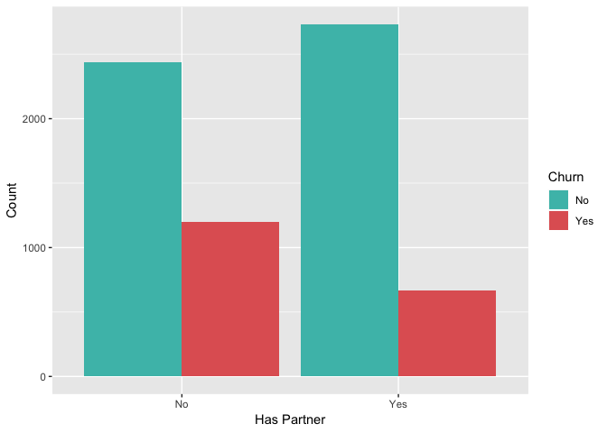

```r
# Color values so churn is denoted as red
val = c("#49beb7","#e16262")

# Function plots proportion and frequency of feature variables relative to churn
plawt <- function(A) {
  ggplot(telco, aes(x = factor(A), fill = factor(Churn))) +
  geom_bar(position = "dodge") +
  scale_y_continuous("Count")+
  scale_fill_manual("Churn", values = val)
}

# Plotting Partner Column
plawt(telco$Partner) + scale_x_discrete("Has Partner")
```

```r
prop.table(table(telco$Partner, telco$Churn),1)
```

```
##
##              No       Yes
##   No  0.6704202 0.3295798
##   Yes 0.8033510 0.1966490
```

top

#### Customer Gender

- Gender proportion is split evenly
- Neither gender is partcularly more likely to churn

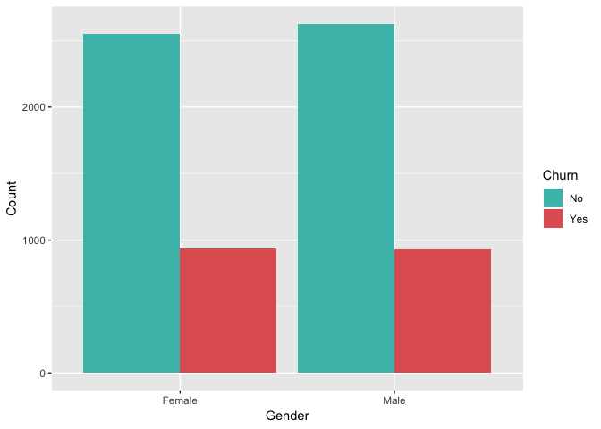

```
##
##                 No       Yes
##   Female 0.7307913 0.2692087
##   Male   0.7383966 0.2616034
```

top

#### Senior Citizens

- Senior Citizens are approximately twice as likely to churn
- Senior Citizens comprise 16% of the customer base

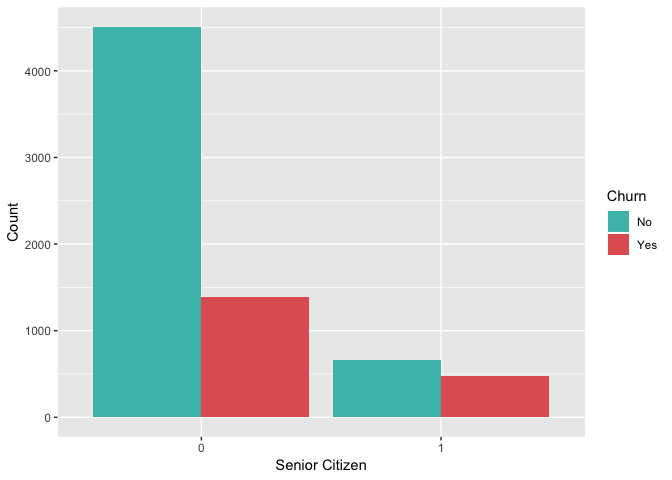

```
##
##            No       Yes
##   0 0.7639383 0.2360617
##   1 0.5831874 0.4168126
```

top

#### Customers with Dependents

- Customers with no dependents churn at twice the rate of those without

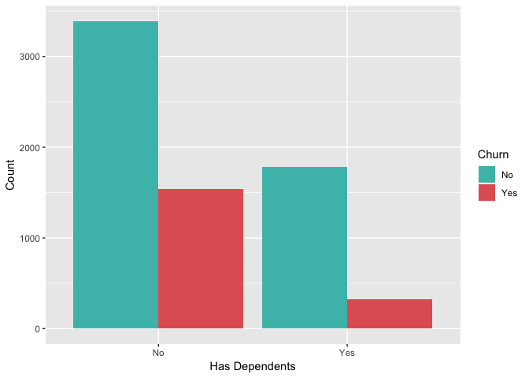

```
##
##              No       Yes
##   No  0.6872086 0.3127914
##   Yes 0.8454976 0.1545024
```

top

## Exploring Adoption Data

- Phone Service
- Multiple Lines
- Internet Service
- Online Security
- Online Backup
- Device Protection
- Tech Support
- Steaming TV
- Streaming Movies
- Index

#### Has Phone Service

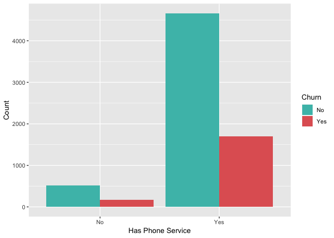

```
##
##              No       Yes
##   No  0.7507331 0.2492669
##   Yes 0.7329036 0.2670964
```

top

#### Has Multiple Lines

- Users with multiple lines to churn at a higher rate than users without multiple lines

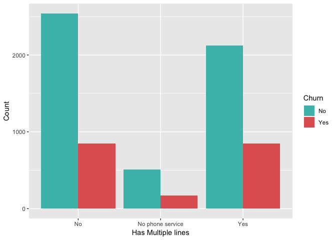

```
##
##                           No       Yes
##   No               0.7495575 0.2504425
##   No phone service 0.7507331 0.2492669
##   Yes              0.7139010 0.2860990
```

top

#### Internet Service

- Fiber Optic Subscribers Churn at a ~42% rate compared with 19% for DSL

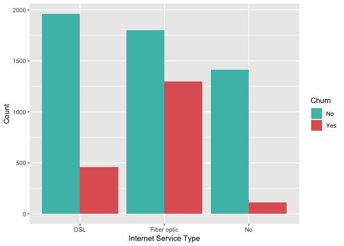

```
##
##                      No       Yes
##   DSL         0.8104089 0.1895911
##   Fiber optic 0.5810724 0.4189276
##   No          0.9259502 0.0740498
```

top

#### Online Security

- Subsribers without Online Security churn at a ~42% rate compared with users with online security who churn at an ~15% rate.

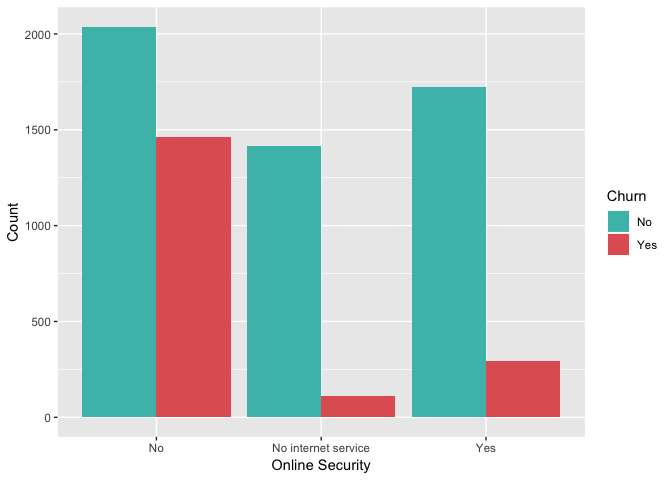

```
##
##                              No       Yes
##   No                  0.5823328 0.4176672
##   No internet service 0.9259502 0.0740498
##   Yes                 0.8538881 0.1461119
```

top

#### Online Backup

- Subsribers without Online Backup churn at a ~40% rate compared with users with online security who churn at an ~21% rate.

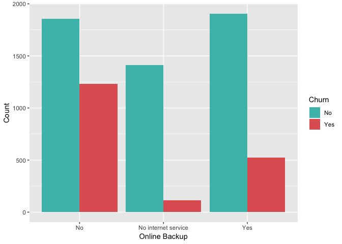

```
##
##                              No       Yes
##   No                  0.6007124 0.3992876
##   No internet service 0.9259502 0.0740498
##   Yes                 0.7846851 0.2153149
```

top

#### Device Protection

- Customers without Device Protection Churn at a 39% Rate compared with a 22% rate for customers with Device Protection

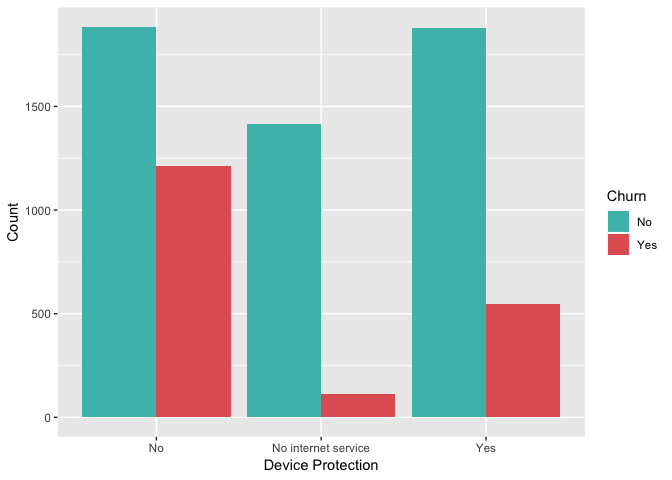

```
##
##                              No       Yes
##   No                  0.6087237 0.3912763
##   No internet service 0.9259502 0.0740498
##   Yes                 0.7749794 0.2250206
```

top

#### Tech Support

- Customers with Tech Support churned at a 15% rate compared with 42% for customers without Tech Support (Whatever this means)

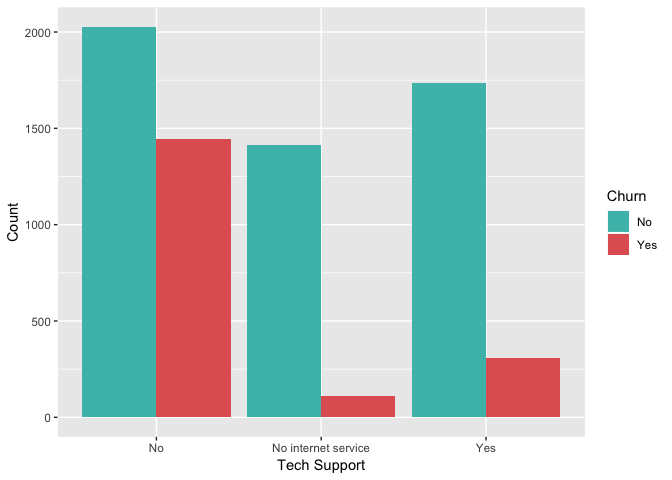

```
##
##                              No       Yes
##   No                  0.5836453 0.4163547
##   No internet service 0.9259502 0.0740498
##   Yes                 0.8483366 0.1516634
```

top

#### Streaming TV

- There is not a meaningful difference in churn rate

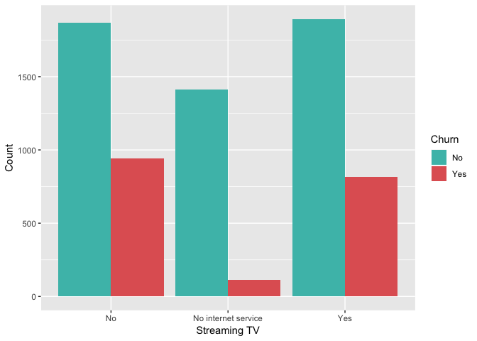

```
##
##                              No       Yes
##   No                  0.6647687 0.3352313
##   No internet service 0.9259502 0.0740498
##   Yes                 0.6992981 0.3007019
```

top

#### Streaming Movies

- There is not a meaningful difference in churn rate

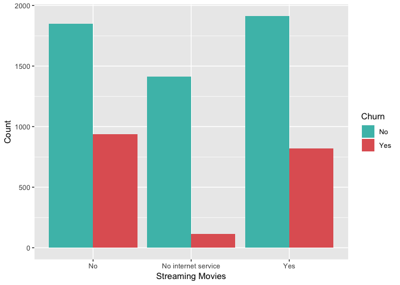

```
##
##                              No       Yes
##   No                  0.6631957 0.3368043
##   No internet service 0.9259502 0.0740498
##   Yes                 0.7005857 0.2994143
```

top

## Exploring Payment Data

- Payment Method and Contract
- Payment and Contract Plot
- Monthly Charges Histogram
- Monthly Charges in Quartiles
- Monthly Charges in Quartiles Plot
- Customer Tenure Code
- Customer Tenure Plot
- Index

#### Payment Method and Contract

- Plotting Payment Variables
- Payment Method
- Contract Type

```r
#Plotting payment and contract variables
payment_plot <- ggplot(telco,aes(x=PaymentMethod,fill=Churn))+
  geom_bar(position="Fill")+
  facet_grid(.~ Contract)+
  theme(axis.text = element_text(angle = 90, hjust=1))+
  scale_fill_manual(values = val)
```

top

#### Payment and Contract Plot

- Not surprisingly, Month-to-Month Payment plans Churn at a higher rate
- When controlling for Contract Type, the electronic check method has the highest churn rate

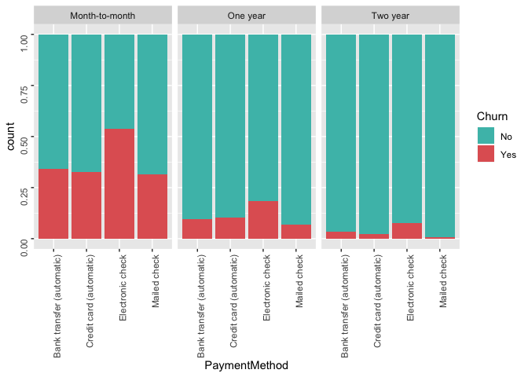

top

#### Monthly Charges Histogram

- Customers churn at a far lower rate in the first paymnent quartile
- Surprisingly, Customers churn less in the 4th quartile than the third
- The likelihood to Churn is not perfectly linear to paymnent

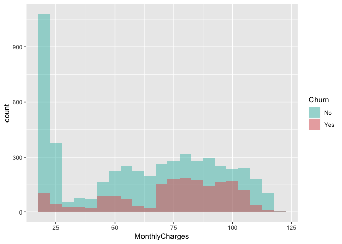

```r
# histograme of monthly payment amounts by churn laid over one another
monthly_histo_plawt <- ggplot(telco, aes(x = MonthlyCharges,fill=Churn)) +
  geom_histogram(binwidth=5,position="identity",alpha=0.5)+
  scale_fill_manual("Churn", values = val)

monthly_histo_plawt
```

top

#### Monthly Charges in Quartiles

- Another look at churn rates by payment amount
- Customers who pay between $70 and $90 churn at a ~38% clip

```r
# creating a dataframe to explore payment data
monthlyfeedf <- telco[19:21]

# grouping monthly payment amounts into quartiles for analsis
monthlyfeedf <- monthlyfeedf %>% mutate(monthly_quartiles = case_when(
  MonthlyCharges <= 35.50 ~ "1st Quartile",
  MonthlyCharges > 35.50  &  MonthlyCharges <= 70.35 ~ "2nd Quartile",
  MonthlyCharges > 70.35  &  MonthlyCharges <= 89.85 ~ "3rd Quartile",
  MonthlyCharges > 89.85  ~ "4th Quartile"
))

# Proportion table to show churn rate by monthly payment amound quartiles
prop.table(table(monthlyfeedf$monthly_quartiles, monthlyfeedf$Churn),1)
```

```
##
##                       No       Yes
##   1st Quartile 0.8876277 0.1123723
##   2nd Quartile 0.7542469 0.2457531
##   3rd Quartile 0.6249289 0.3750711
##   4th Quartile 0.6712173 0.3287827
```

```r
# Plotting monthly payment amound quartiles
pay_plawt <- ggplot(monthlyfeedf, aes(x = factor(monthly_quartiles), fill = factor(Churn))) +
  geom_bar(position = "dodge") +
  scale_y_continuous("Customers")+
  scale_fill_manual("Churn", values = val)+
  scale_x_discrete("Monthly Payment Amount")
```

top

#### Monthly Charges in Quartiles Plot

- Another look at churn rates by payment amount

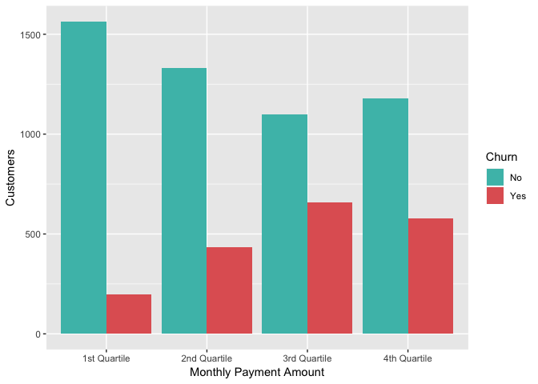

top

#### Customer Tenure

- While only 15% of customers churn in the first year, first year cancellations account for more than ~55% all customer Churn.

```r
tenuredf <- telco[6]

tenuredf <- tenuredf %>%
  bind_cols(monthlyfeedf)

# creating a new colmn called cohort for plotting.
tenuredf <- tenuredf %>% mutate(cohort= case_when(
  tenure <= 12 ~ "Year 1",
  tenure > 12 & tenure <= 24 ~ "Year 2",
  tenure > 24 & tenure <= 36 ~ "Year 3",
  tenure > 36 & tenure <= 48 ~ "Year 4",
  tenure > 48 & tenure <= 60 ~ "Year 5",
  tenure > 60 ~ "Year 6 & Beyond"
))

# number of 7043 customers who have churned in given tenure cohorts
tenuredf %>%
  filter(Churn == "Yes") %>%
  select(Churn, cohort) %>%
  group_by(cohort) %>%
  summarise(n(),n()/7043)
```

```
## # A tibble: 6 x 3
##   cohort          `n()` `n()/7043`
##   <chr>           <int>      <dbl>
## 1 Year 1           1037     0.147
## 2 Year 2            294     0.0417
## 3 Year 3            180     0.0256
## 4 Year 4            145     0.0206
## 5 Year 5            120     0.0170
## 6 Year 6 & Beyond    93     0.0132
```

```r
# I just want to plot churn in the various cohorts
tenure_churn <- tenuredf %>%
  filter(Churn == "Yes") %>%
  select(cohort,Churn)

# plotting churn in the various cohorts, and making it this pretty red
tenure_plawt <- ggplot(tenure_churn, aes(x = factor(cohort), fill = factor(Churn))) +
  geom_bar(position = "stack") +
  scale_y_continuous("Customers")+
  scale_fill_manual("Churn", values = "#e16262")+
  scale_x_discrete("Tenure at time of Churn")
```

top

#### Customer Tenure Plot

- First year cancellations account for more than 55% all customer Churn.

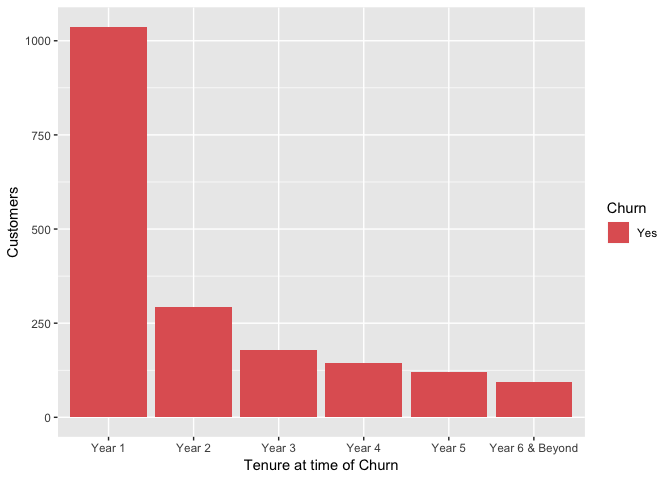

top

## Tidying Data

- Dummy Variables Function
- Creating Dummy Variables
- Payment Features Data Frame
- Demographic Features Data Frame
- Prepping Adoption Variables
- Adoption Features Data Frame
- Index

#### Dummy Variables Function

```r
# Renaming PaymentMethod elements for plot labels.
telco <- telco %>%
  mutate(PaymentMethod= case_when(
  str_detect(PaymentMethod, "Bank") ~ "Bank Transfer",
  str_detect(PaymentMethod, "Credit") ~ "Credit Card",
  T ~ PaymentMethod
  ))

# dumz function converts categorical variables in the telco date frame into dummy variables
dumz <- function(x) {
  telco %>%
  mutate(var = 1) %>%
  spread(x, var, fill = 0, sep = "_") %>%
  select(21:last_col())
}
```

top

#### Creating Dummy Variables

- Converting PaymentMethod and Contract Elements into Dummy Variables

```r
#applying the dummiez function on the `Payment` column
payment_dummy <- dumz("PaymentMethod")
#applying the dummiez function on the `Contract` column
contract_dummy <- dumz("Contract")
```

top

#### Payment Features Data Frame

- Combining Payment-related variables to create a Payment Features Data Frame

```r
#creates a dataframe comprising the churn column from the telco dataset
monthlydf <- telco[19]
churndf <- telco[21]
# combing the contract_dummy and payment_dummy data frames.
payment_features <- payment_dummy %>%
  bind_cols(contract_dummy,monthlydf,churndf)

glimpse(payment_features)
```

```
## Observations: 7,043
## Variables: 9
## $ `PaymentMethod_Bank Transfer`    <dbl> 0, 0, 0, 1, 0, 0, 0, 0, 0, 1, 0…
## $ `PaymentMethod_Credit Card`      <dbl> 0, 0, 0, 0, 0, 0, 1, 0, 0, 0, 0…
## $ `PaymentMethod_Electronic check` <dbl> 1, 0, 0, 0, 1, 1, 0, 0, 1, 0, 0…
## $ `PaymentMethod_Mailed check`     <dbl> 0, 1, 1, 0, 0, 0, 0, 1, 0, 0, 1…
## $ `Contract_Month-to-month`        <dbl> 1, 0, 1, 0, 1, 1, 1, 1, 1, 0, 1…
## $ `Contract_One year`              <dbl> 0, 1, 0, 1, 0, 0, 0, 0, 0, 1, 0…
## $ `Contract_Two year`              <dbl> 0, 0, 0, 0, 0, 0, 0, 0, 0, 0, 0…
## $ MonthlyCharges                   <dbl> 29.85, 56.95, 53.85, 42.30, 70.…
## $ Churn                            <chr> "No", "No", "Yes", "No", "Yes",…
```

top

#### Demographic Features Data Frame

- Combining Demographic-related variables to create a Demographic Features Data Frame

```
## Observations: 7,043
## Variables: 5
## $ gender        <chr> "Female", "Male", "Male", "Male", "Female", "Femal…
## $ SeniorCitizen <dbl> 0, 0, 0, 0, 0, 0, 0, 0, 0, 0, 0, 0, 0, 0, 0, 0, 0,…
## $ Partner       <dbl> 1, 0, 0, 0, 0, 0, 0, 0, 1, 0, 1, 0, 1, 0, 0, 1, 0,…
## $ Dependents    <dbl> 0, 0, 0, 0, 0, 0, 1, 0, 0, 1, 1, 0, 0, 0, 0, 1, 0,…
## $ Churn         <chr> "No", "No", "Yes", "No", "Yes", "Yes", "No", "No",…
```

top

#### Prepping Adoption Variables

```r
adoptiondf <- telco %>%
  select(7:8,10:15)

adoptiondf <- na_if(adoptiondf, "No internet service")
adoptiondf <- na_if(adoptiondf, "No phone service")

adoptiondf <- adoptiondf %>%
    mutate(PhoneService = case_when(
      PhoneService  == "Yes" ~ 1,
      PhoneService  == "No" ~ 0,
      T ~ as.numeric(PhoneService )
    ))

adoptiondf <- adoptiondf %>%
    mutate(MultipleLines   = case_when(
      MultipleLines == "Yes" ~ 1,
      MultipleLines  == "No" ~ 0,
      T ~ as.numeric(MultipleLines )
    ))

adoptiondf <- adoptiondf %>%
    mutate(OnlineBackup= case_when(
      OnlineBackup == "Yes" ~ 1,
      OnlineBackup == "No" ~ 0,
      T ~ as.numeric(OnlineBackup)
    ))

adoptiondf <- adoptiondf %>%
    mutate(OnlineSecurity= case_when(
      OnlineSecurity == "Yes" ~ 1,
      OnlineSecurity == "No" ~ 0,
      T ~ as.numeric(OnlineSecurity)
    ))

adoptiondf <- adoptiondf %>%
    mutate(DeviceProtection= case_when(
      DeviceProtection == "Yes" ~ 1,
     DeviceProtection == "No" ~ 0,
      T ~ as.numeric(DeviceProtection)
    ))

adoptiondf <- adoptiondf %>%
    mutate(TechSupport = case_when(
      TechSupport  == "Yes" ~ 1,
      TechSupport  == "No" ~ 0,
      T ~ as.numeric(TechSupport)
    ))

adoptiondf <- adoptiondf %>%
    mutate(StreamingTV  = case_when(
      StreamingTV   == "Yes" ~ 1,
      StreamingTV   == "No" ~ 0,
      T ~ as.numeric(StreamingTV)
    ))

adoptiondf <- adoptiondf %>%
    mutate(StreamingMovies  = case_when(
      StreamingMovies   == "Yes" ~ 1,
      StreamingMovies   == "No" ~ 0,
      T ~ as.numeric(StreamingMovies)
    ))


Internet_dummy <- dumz("InternetService")
```

top

#### Adoption Features Data Frame

- Combining variables related to product adoption to create an Adoption Features Data Frame

```
## Observations: 7,043
## Variables: 12
## $ PhoneService                  <dbl> 0, 1, 1, 0, 1, 1, 1, 0, 1, 1, 1, 1…
## $ MultipleLines                 <dbl> NA, 0, 0, NA, 0, 1, 1, NA, 1, 0, 0…
## $ OnlineSecurity                <dbl> 0, 1, 1, 1, 0, 0, 0, 1, 0, 1, 1, N…
## $ OnlineBackup                  <dbl> 1, 0, 1, 0, 0, 0, 1, 0, 0, 1, 0, N…
## $ DeviceProtection              <dbl> 0, 1, 0, 1, 0, 1, 0, 0, 1, 0, 0, N…
## $ TechSupport                   <dbl> 0, 0, 0, 1, 0, 0, 0, 0, 1, 0, 0, N…
## $ StreamingTV                   <dbl> 0, 0, 0, 0, 0, 1, 1, 0, 1, 0, 0, N…
## $ StreamingMovies               <dbl> 0, 0, 0, 0, 0, 1, 0, 0, 1, 0, 0, N…
## $ InternetService_DSL           <dbl> 1, 1, 1, 1, 0, 0, 0, 1, 0, 1, 1, 0…
## $ `InternetService_Fiber optic` <dbl> 0, 0, 0, 0, 1, 1, 1, 0, 1, 0, 0, 0…
## $ InternetService_No            <dbl> 0, 0, 0, 0, 0, 0, 0, 0, 0, 0, 0, 1…
## $ Churn                         <chr> "No", "No", "Yes", "No", "Yes", "Y…
```

top

## Correlation Analysis

- Payment Features Correlation
- Demographics Features Correlation
- Adoption Correlation
- Index

#### Payment Features Correlation

```
## # A tibble: 8 x 2
##   feature                          Churn
##   <fct>                            <dbl>
## 1 Contract_Month-to-month         0.405
## 2 PaymentMethod_Electronic check  0.302
## 3 MonthlyCharges                  0.193
## 4 PaymentMethod_Mailed check     -0.0917
## 5 PaymentMethod_Bank Transfer    -0.118
## 6 PaymentMethod_Credit Card      -0.134
## 7 Contract_One year              -0.178
## 8 Contract_Two year              -0.302
```

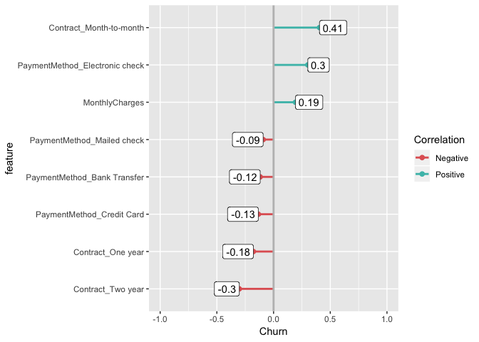

top

#### Demographics Correlation

- correlation table and plot for Demographic Data

```
## # A tibble: 4 x 2
##   feature          Churn
##   <fct>            <dbl>
## 1 SeniorCitizen  0.151
## 2 gender        -0.00861
## 3 Partner       -0.150
## 4 Dependents    -0.164
```

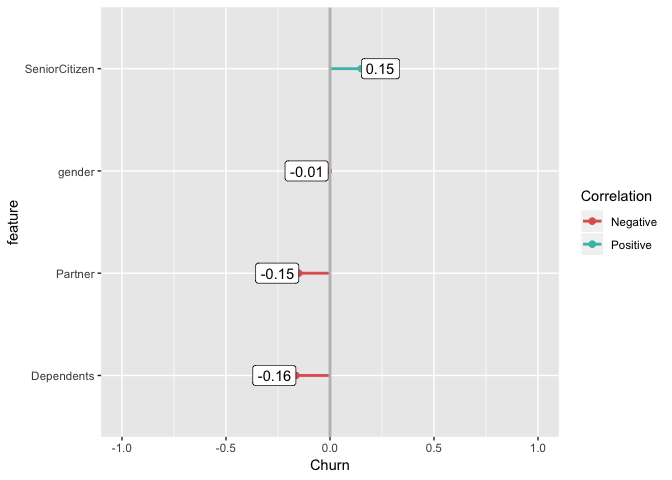

top

#### Adoption Correlation

```
## # A tibble: 11 x 2
##    feature                       Churn
##    <fct>                         <dbl>
##  1 InternetService_Fiber optic  0.308
##  2 MultipleLines                0.0402
##  3 PhoneService                 0.0119
##  4 StreamingTV                 -0.0371
##  5 StreamingMovies             -0.0401
##  6 InternetService_DSL         -0.124
##  7 DeviceProtection            -0.177
##  8 OnlineBackup                -0.196
##  9 InternetService_No          -0.228
## 10 TechSupport                 -0.274
## 11 OnlineSecurity              -0.281
```

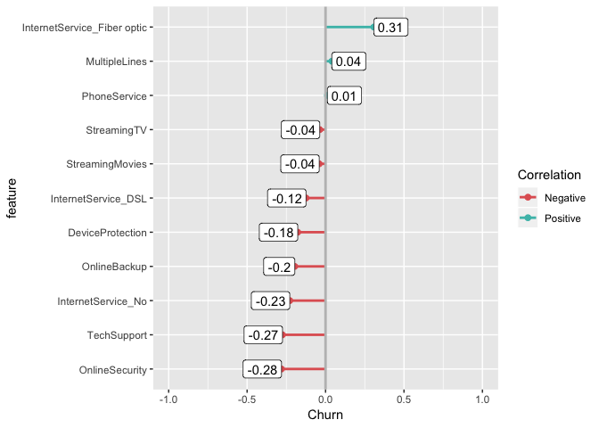

top

## Training Dataset

- Creating Features Dataset
- Index

```r
#Creating 4 datasets with the most highly-correlated features and one for the target variable - churn -- to be combined below into a training dataset
churn_winner <- churndf %>%
    mutate(Churn = ifelse(Churn=="Yes", 1, 0))
demographics_winners <- demo_features[3:4]
adoption_winners <- adoption_features[10]
payment_winners <- payment_features[3]

#Combining all of the crazy sub datasets that I explored above into one dataset
features_data <- demographics_winners %>%
  bind_cols(adoption_winners,payment_winners,monthlydf,churn_winner)

# I have to change the column or variable names for these two columns that were created via the spread function.
names(features_data)[3] <- "Fiber_Optic"
names(features_data)[4] <- "Electronic_Check"
```

## Decision Tree

- Decision Tree
- Changing Features Data
- Index

#### Decision Tree

- With the supposed leading churn factures bundled together in a single dataframe, the goal here is to use a decision tree aglorithm to ensure the factors aren’t too confounded by other variables and actually warrant being used in a predictive model.
- The results of the decision tree show that Fiber Optic and Electronic Check are the two most significant factors.
- Monthly Charges is broken into two groups, which is what the proportional tables above show.
- Dependents doesn’t make it asa node in the decision tree, possibly because the variable is confounded by the Partner variable.

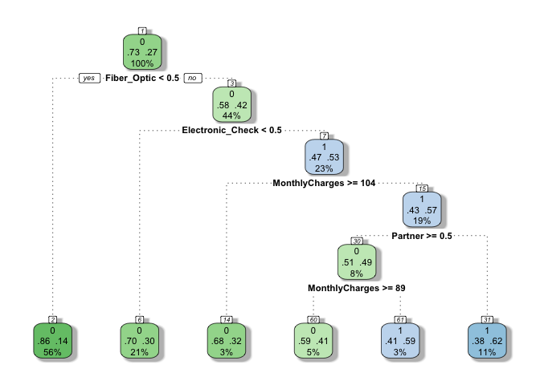

top

#### Changing Features Data

- Based on the results of our Decision Tree, Dependents are not deemed to have enough predictve Power, so they are removed from the features_data data set

```
## Observations: 7,043
## Variables: 5
## $ Partner          <dbl> 1, 0, 0, 0, 0, 0, 0, 0, 1, 0, 1, 0, 1, 0, 0, 1,…
## $ Fiber_Optic      <dbl> 0, 0, 0, 0, 1, 1, 1, 0, 1, 0, 0, 0, 1, 1, 1, 1,…
## $ Electronic_Check <dbl> 1, 0, 0, 0, 1, 1, 0, 0, 1, 0, 0, 0, 0, 0, 1, 0,…
## $ MonthlyCharges   <dbl> 29.85, 56.95, 53.85, 42.30, 70.70, 99.65, 89.10…
## $ Churn            <fct> 0, 0, 1, 0, 1, 1, 0, 0, 1, 0, 0, 0, 0, 1, 0, 0,…
```

top

## Splitting Dataset for Testing

- Splitting Dataset for Testing
- Index

#### Splitting Dataset for Testing

```r
#The createDataPartition() function that comes with the caret package can be used to split the data.
library(caret)
#Here I am creating an object that is 80% of the features_data dataset
inTrain <- createDataPartition(y= features_data$Churn, p=0.8, list=FALSE)

#Here I am creating training dataset witht he inTrain object being the subest of the features-data dataset on which we want to fit our model
training <- features_data[inTrain, ]

#Here I am creating test dataset, which is 20% of the features_data dataset
test <- features_data[-inTrain, ]
```

top

## Logistic Regression

- Fitting the Model
- Index

```r
#logistic regression Fitting the Model on Training DataSet
glm.training <- glm(Churn ~ Partner + Fiber_Optic + Electronic_Check + MonthlyCharges, data = training, family = binomial)
summary(glm.training)
```

```
##
## Call:
## glm(formula = Churn ~ Partner + Fiber_Optic + Electronic_Check +
##     MonthlyCharges, family = binomial, data = training)
##
## Deviance Residuals:
##     Min       1Q   Median       3Q      Max
## -1.4881  -0.6993  -0.4909   0.9218   2.4667
##
## Coefficients:
##                   Estimate Std. Error z value Pr(>|z|)
## (Intercept)      -1.289972   0.099619 -12.949  < 2e-16 ***
## Partner          -0.676801   0.068305  -9.909  < 2e-16 ***
## Fiber_Optic       1.708954   0.124071  13.774  < 2e-16 ***
## Electronic_Check  1.049446   0.068707  15.274  < 2e-16 ***
## MonthlyCharges   -0.011105   0.002071  -5.361 8.28e-08 ***
## ---
## Signif. codes:  0 '***' 0.001 '**' 0.01 '*' 0.05 '.' 0.1 ' ' 1
##
## (Dispersion parameter for binomial family taken to be 1)
##
##     Null deviance: 6522.7  on 5635  degrees of freedom
## Residual deviance: 5587.6  on 5631  degrees of freedom
## AIC: 5597.6
##
## Number of Fisher Scoring iterations: 4
```

```r
# applying modelt to test data set. creating an object `p` which is the predict function applying the glm.training model to the test dataset. The output is a probability from 0 to 1.
Predictarino <- predict(glm.training,test,type = "response")

summary(Predictarino)
```

```
##    Min. 1st Qu.  Median    Mean 3rd Qu.    Max.
## 0.04785 0.11182 0.18822 0.25922 0.37612 0.66781
```

```r
#Predicting Churn outcome by applying a threshold of 0.5. If the probability is above, it is a churn.
churnono <- ifelse(Predictarino  > 0.5, 1, 0)

table(churnono)
```

```
## churnono
##    0    1
## 1226  181
```

```r
p_churn <- factor(churnono, levels = levels(test[["Churn"]]))

#using caret's helper fuction to
confusionMatrix(p_churn,test[["Churn"]])
```

```
## Confusion Matrix and Statistics
##
##           Reference
## Prediction   0   1
##          0 962 264
##          1  72 109
##
##                Accuracy : 0.7612
##                  95% CI : (0.738, 0.7833)
##     No Information Rate : 0.7349
##     P-Value [Acc > NIR] : 0.01308
##
##                   Kappa : 0.2664
##
##  Mcnemar's Test P-Value : < 2e-16
##
##             Sensitivity : 0.9304
##             Specificity : 0.2922
##          Pos Pred Value : 0.7847
##          Neg Pred Value : 0.6022
##              Prevalence : 0.7349
##          Detection Rate : 0.6837
##    Detection Prevalence : 0.8714
##       Balanced Accuracy : 0.6113
##
##        'Positive' Class : 0
##
```

top

```
##
## Call:
## glm(formula = Churn ~ Fiber_Optic, family = binomial, data = training)
##
## Deviance Residuals:
##     Min       1Q   Median       3Q      Max
## -1.0403  -1.0403  -0.5612   1.3210   1.9627
##
## Coefficients:
##             Estimate Std. Error z value Pr(>|z|)
## (Intercept) -1.76867    0.05044  -35.06   <2e-16 ***
## Fiber_Optic  1.43731    0.06483   22.17   <2e-16 ***
## ---
## Signif. codes:  0 '***' 0.001 '**' 0.01 '*' 0.05 '.' 0.1 ' ' 1
##
## (Dispersion parameter for binomial family taken to be 1)
##
##     Null deviance: 6522.7  on 5635  degrees of freedom
## Residual deviance: 5991.0  on 5634  degrees of freedom
## AIC: 5995
##
## Number of Fisher Scoring iterations: 4
```

```
## (Intercept) Fiber_Optic
##    0.145708    0.808038
```

```
## (Intercept)
##   0.4179104
```

```
##         1
## 0.4179104
```

top